# Colgate vs Crest

FRANCISCO DEL VAL

23/11/2020

## Introducción

Procter y Gamble introdujeron Crest en el mercado estadounidense en 1956. Antes de ese momento, Colgate disfrutaba de un liderazgo de mercado con una participación de mercado cercana al 50%. Durante los siguientes 4 años, Colgate siguió siendo un competidor dominante y Crest solo logró una participación de mercado relativamente modesta pero estable del 15%. Sin embargo, el 1 de agosto de 1960, el Consejo de Terapéutica Dental de la American Dental Association (ADA) aprobó a Crest como una “ayuda importante en cualquier programa de higiene dental”. Mientras tanto, Procter y Gamble revitalizaron su campaña de marketing para aprovechar el respaldo de la ADA, lo que dio como resultado un salto casi inmediato en la cuota de mercado de Crest en detrimento de la de Colgate.

## Desarrollo

Los datos se sitúan en un intervalo de tiempo semanal desde 1958 hasta abril de 1963 y no presenta valores perdidos ni erróneos. La confirmación y emisión del certificado de calidad de la ADA se produce el 1 de agosto de 1960, momento considerado como cambio en la serie temporal de las cuotas de mercado de las pastas de dientes. En la siguiente representación de ambas series (Colgate y Crest) localizamos de una manera directa el momento en el que Crest irrumpe en el mercado y comienza a incrementar sus ventas viéndose afectadas las ventas de Colgate que comienzan a decrecer.

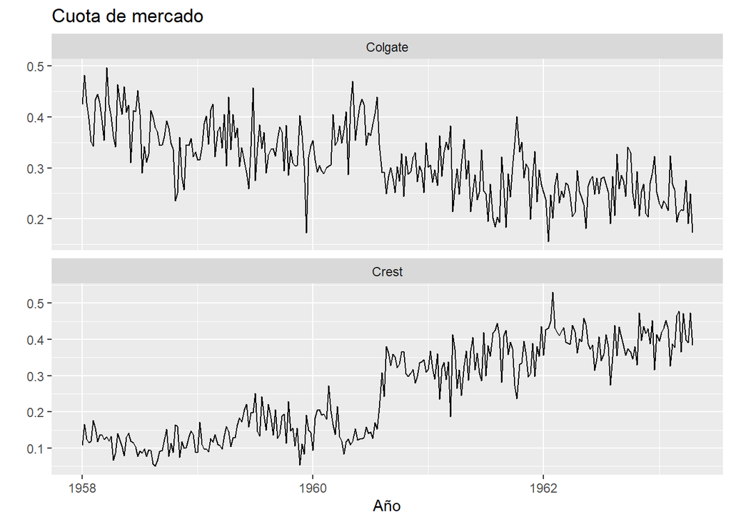

Ambas series temporales son no estacionarias (no es constante ni en media ni en varianza) aplico logaritmos para convertirla en estacionaria en varianza. Para convertirlo en estacionario en media utilizaremos las diferencias. Además, de tendencia positiva en el caso de Crest y una tendencia decreciente en el caso de Colgate.

Como podemos observar, en el gráfico de colgate observamos que en el año 1959 exite un efecto puntual. Y en el gráfico de crest observamos que a mediados de 1960 existe un efecto permanente.

Tras la intervención de la ADA, Colgate pasa de una cuota de mercado del 45% al 25% en cuestion de 6 meses. Crest, al contario, amplía su cuota de mercado del 10% al casi 40% en un intervalo de 6 meses desde la intervención de la ADA.

Se eliminaran las 16 últimas semanas para realizar la predicción.

### OUTLIERS

Suponen cambios en las series temporales que producen variaciones. Son muy importantes para el análisis porque el posterior efecto de intervención puede haber sido causado por uno de estos.

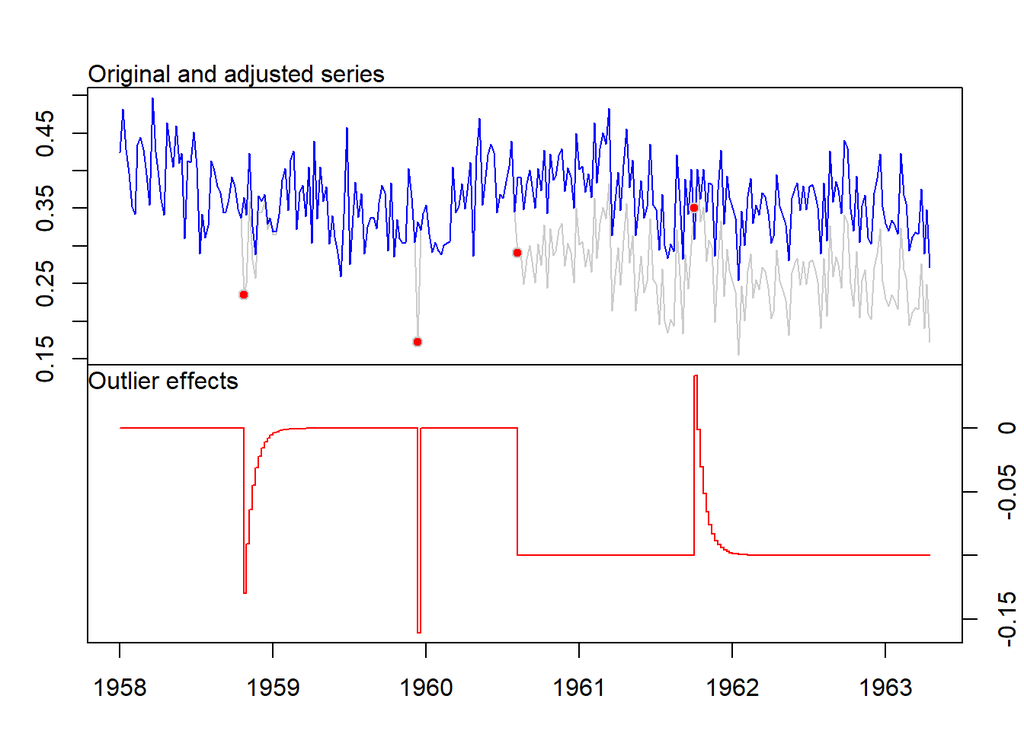

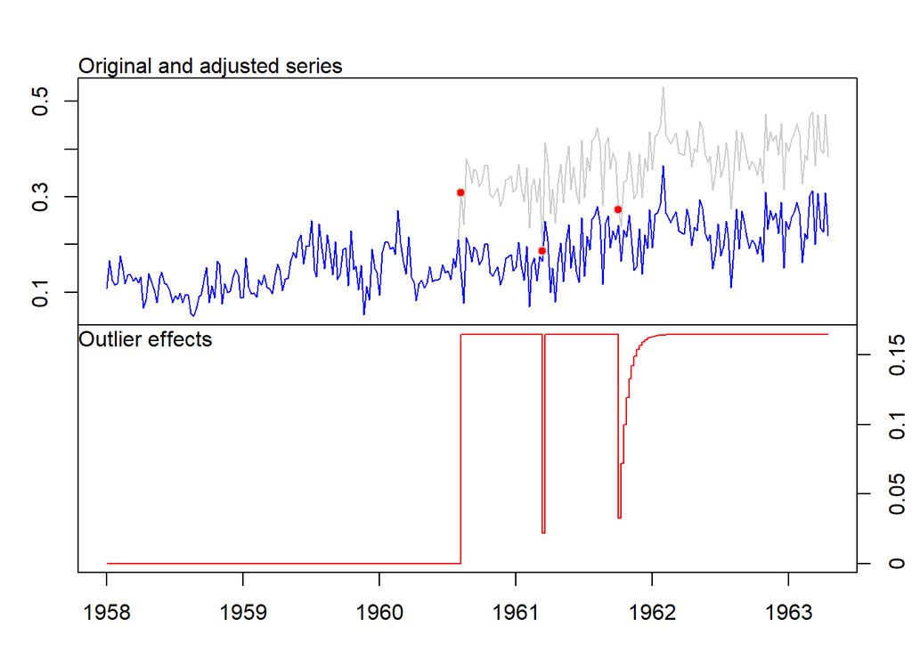

Seguidamente, realizamos el modelo de intervención para analizar las series temporales sin los outliers correspondientes.

El objetivo de la intervención es ver la evolución de la serie si no se hubiese producido ningún tipo de intervención.

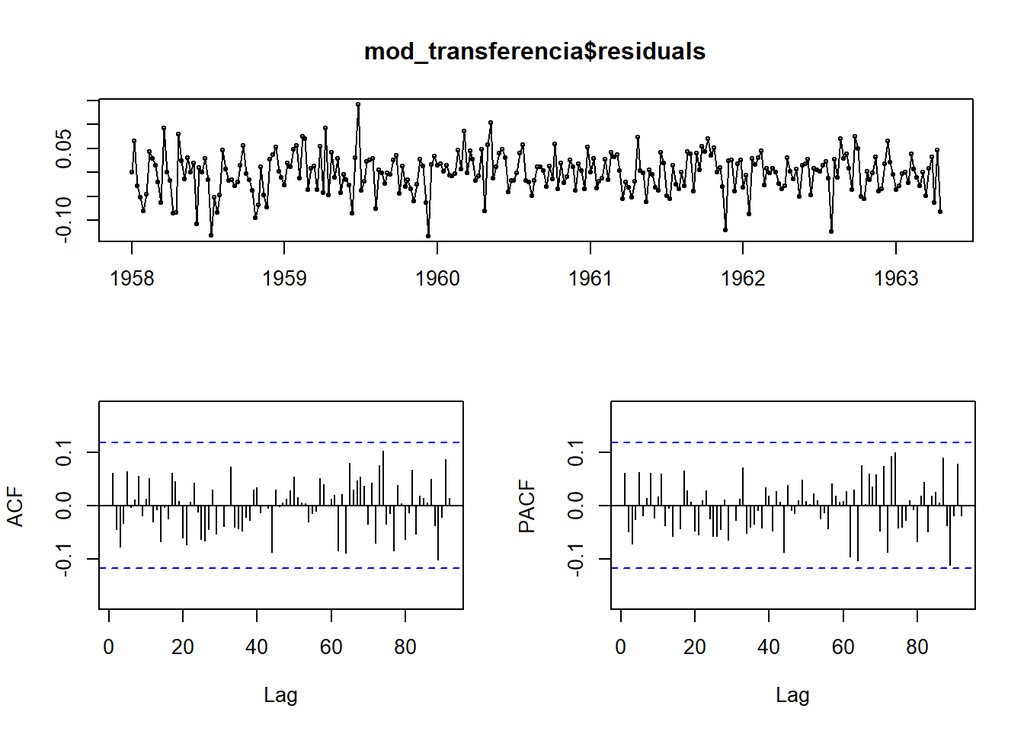

La función de transferencia es la que tiene efecto sobre la intervención, se calcula o con la función de impulso o bien con la de salto. Ambas afectan a la permanencia y al dinamismo ya que, cuando las condiciones cambian con el tiempo, los modelos se pueden ajustar aun más introduciendo los inputs que reflejarían los cambios en las condiciones del proceso.

Para finalizar, hemos predecido el año 1963

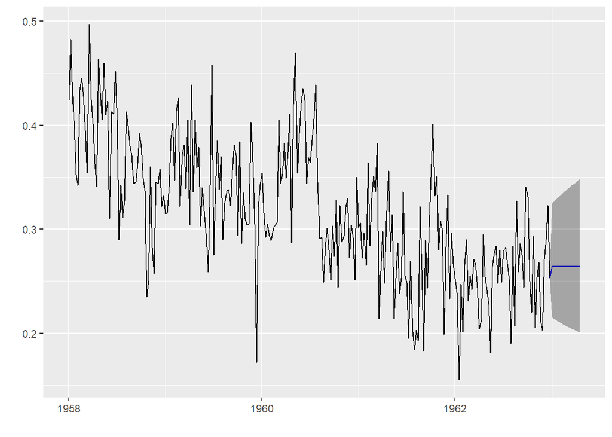

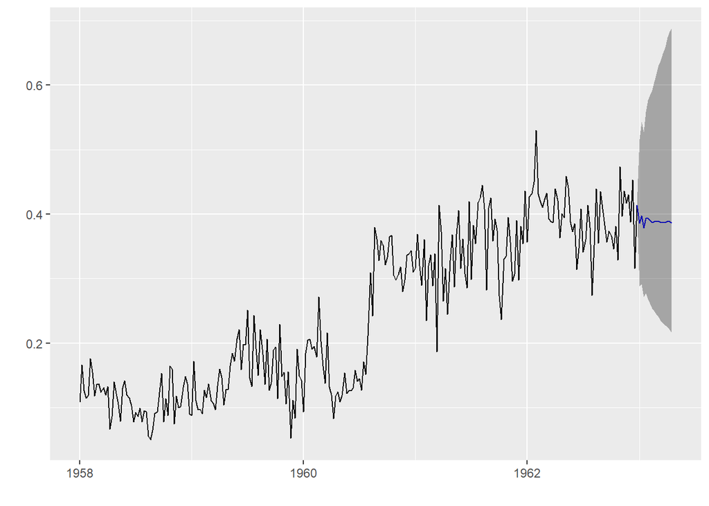

Como podemos observar en los graficos, la prediccion consolida Crest como lider en el mercado de las pastas dentrificas.

## Conclusiones

Sucesos fuera del comportamiento de la empresa tienen que tenerse en cuenta y saber responder ante ellos. En nuestro informe, P&G utiliza el anuncio de la ADA para crear una campaña publicitario fuerte, consigiendo ser la marca lider del mercado.

Por otro lado, colgate debio crear alguna modelo innovativo en respuesta al anuncio de ADA. Entre otras cosas, esta fue una de las razones por la que crest se convirtio en lider, la respuesta tardía del resto de marcas.